# SUNFISH Simulation Results Analysis

2025-12-03

# SUNFISH Simulation Analysis

This document analyzes the performance of different estimators in the SUNFISH Part 2 trial simulation across 6 scenarios with varying degrees of regional and treatment heterogeneity.

**Endpoint**: Continuous (Change from baseline in MFM32 score)  
**Effect Metric**: Mean Difference (Treatment - Control)  
**Sample Size**: N=180 (120 Risdiplam : 60 Placebo)

## 1. Setup and Configuration

```r
# Define endpoint parameters for continuous outcome
ENDPOINT_ID <- 'SUNFISH'

ep_params <- list(
  folder = "SUNFISH",
  truth_list_name = "simul_truth",
  truth_overall_name = "truth_overall",
  truth_subgroup_name = "truth_subgroup",
  truth_metric_exp = "value",  # Mean difference (no exponentiation)
  est_metric = "MeanDiff",
  est_col = "estimate",
  ci_low = "lower_ci",
  ci_up = "upper_ci",
  log_truth_col = "value"
)

cat("Analyzing SUNFISH simulation results...\n")
```

```
## Analyzing SUNFISH simulation results...
```

```r
cat("Endpoint:", ep_params$est_metric, "\n")
```

```
## Endpoint: MeanDiff
```

## 2. Load Results Files

```r
# Find all results files
results_path <- file.path("Results")
all_files <- list.files(results_path, pattern = "\\.rds$", full.names = TRUE)

cat("Found", length(all_files), "results files:\n")
```

```
## Found 2 results files:
```

```r
cat(paste("-", basename(all_files), collapse = "\n"), "\n")
```

```
## - SUNFISH_population.rds
## - SUNFISH_subgroup.rds
```

```r
# Helper function to load and validate results
load_and_validate_rds <- function(file_path) {
  message(paste("Loading:", basename(file_path)))

  df <- readRDS(file_path)

  # Determine ID columns based on file type
  if ("scenario_id" %in% names(df)) {
    n_sims <- df %>% distinct(scenario_id, replication_id) %>% nrow()
    id_cols <- c("scenario_id", "replication_id")
  } else if ("scenario_no" %in% names(df)) {
    n_sims <- df %>% distinct(scenario_no, simul_no) %>% nrow()
    id_cols <- c("scenario_no", "simul_no")
  } else {
    warning(paste("Could not identify ID columns in:", basename(file_path)))
    return(NULL)
  }

  # Validate expected number of simulations (6 scenarios × 1000 reps = 6000)
  if (n_sims != 6000) {
    warning(sprintf("File %s is incomplete! Expected 6000 sims, found %d.",
                    basename(file_path), n_sims))
  } else {
    message(paste("  ✓ Validation OK:", n_sims, "simulations found"))
  }

  # Add metadata
  df %>% mutate(
    file_name = basename(file_path),
    estimator_name = str_remove(file_name, paste0("^", ENDPOINT_ID, "_")) %>%
                     str_remove("\\.rds$")
  )
}

# Load all files
all_results_list <- lapply(all_files, load_and_validate_rds)
all_results_list <- all_results_list[!sapply(all_results_list, is.null)]

cat("\n✓ Successfully loaded", length(all_results_list), "result files\n")
```

```
##
## ✓ Successfully loaded 2 result files
```

## 3. Load Truth Data

```r
# Load the true treatment effects
truth_file <- file.path("Scenarios", "truth.RData")

if (!file.exists(truth_file)) {
  stop("Truth file not found! Please run Truth.Rmd first to generate truth.RData")
}

load(truth_file)  # Loads simul_truth

cat("✓ Loaded truth data from:", truth_file, "\n")
```

```
## ✓ Loaded truth data from: Scenarios/truth.RData
```

```r
# Standardize truth data for merging
real_params_tidy <- simul_truth[[ep_params$truth_subgroup_name]] %>%
  mutate(
    # Create join_key: x_1.2-5y -> 12-5y (remove x_ and first dot)
    join_key = gsub("^x_", "", subgroup) %>% sub("\\.", "", .),
    scenario_no = as.character(scenario)
  ) %>%
  rename(
    truth_value = !!sym(ep_params$log_truth_col)
  ) %>%
  select(scenario_no, join_key, truth_value)

# Get population-level truth for heterogeneity flagging
true_population_results <- simul_truth[[ep_params$truth_overall_name]] %>%
  mutate(
    scenario_no = as.character(scenario),
    truth_population = value
  ) %>%
  select(scenario_no, truth_population)

cat("✓ Truth data standardized\n")
```

```
## ✓ Truth data standardized
```

```r
cat("  - Subgroups:", nrow(real_params_tidy), "\n")
```

```
##   - Subgroups: 102
```

```r
cat("  - Scenarios:", n_distinct(real_params_tidy$scenario_no), "\n")
```

```
##   - Scenarios: 6
```

## 4. Standardize All Results

```r
# Standardize results from different estimator types
standardized_results_list <- lapply(all_results_list, function(df) {

  estimator_type <- df$estimator_name[1]

  if (estimator_type == "population") {
    # Population estimator: overall estimate replicated across subgroups
    # Deduplicate by taking first row per scenario/simulation
    df %>%
      group_by(scenario_no, simul_no) %>%
      slice(1) %>%
      ungroup() %>%
      mutate(
        scenario_id = as.integer(scenario_no),
        replication_id = as.integer(simul_no),
        estimate_value = estimate,
        ci_lower = lower_ci,
        ci_upper = upper_ci,
        estimator_name = estimator
      ) %>%
      select(scenario_id, replication_id, estimator_name,
             estimate_value, ci_lower, ci_upper)

  } else if (estimator_type == "subgroup") {
    # Subgroup estimator: subgroup-specific estimates
    # Subgroup names are like S_1.12-17y, so remove S_ and first dot to get 112-17y
    df %>%
      mutate(
        join_key = gsub("^S_", "", subgroup) %>% sub("\\.", "", .),
        scenario_id = as.integer(scenario_no),
        replication_id = as.integer(simul_no),
        estimate_value = estimate,
        ci_lower = lower_ci,
        ci_upper = upper_ci,
        estimator_name = estimator
      ) %>%
      select(scenario_id, replication_id, estimator_name, join_key,
             estimate_value, ci_lower, ci_upper)

  } else {
    # bonsaiforest2 global/OVAT models
    # Subgroup names are like x_1: 2-5y, so remove x_, space and colon to get 12-5y
    df %>%
      filter(Subgroup != "Overall") %>%
      mutate(
        join_key = gsub("^x_", "", Subgroup) %>%
                   gsub(": ", "", .) %>%
                   gsub(" ", "", .),
        estimator_name = paste(model_type, prior_name, sep = "_")
      ) %>%
      rename(
        estimate_value = Median,
        ci_lower = CI_Lower,
        ci_upper = CI_Upper
      ) %>%
      select(scenario_id, replication_id, estimator_name, join_key,
             estimate_value, ci_lower, ci_upper)
  }
})

# Combine all results
all_estimators_df <- bind_rows(standardized_results_list)
all_estimators_df$scenario_no <- as.character(all_estimators_df$scenario_id)

cat("✓ Standardized", nrow(all_estimators_df), "estimate records\n")
```

```
## ✓ Standardized 108000 estimate records
```

```r
cat("✓ Estimators:", paste(sort(unique(all_estimators_df$estimator_name)), collapse = ", "), "\n")
```

```
## ✓ Estimators: population, subgroup
```

## 5. Merge Results with Truth

```r
# Separate population and subgroup estimators for different truth matching
population_estimators <- all_estimators_df %>%
  filter(estimator_name == "population") %>%
  # Population estimator: deduplicate (same estimate for all subgroups) and match to overall truth
  distinct(scenario_id, replication_id, estimator_name, estimate_value, ci_lower, ci_upper) %>%
  mutate(scenario_no = as.character(scenario_id)) %>%
  left_join(true_population_results, by = "scenario_no") %>%
  rename(truth_value = truth_population)

subgroup_estimators <- all_estimators_df %>%
  filter(estimator_name != "population") %>%
  # Subgroup estimators: match to subgroup-specific truth
  left_join(real_params_tidy, by = c("scenario_no", "join_key")) %>%
  left_join(true_population_results, by = "scenario_no")

# Combine back together
merged_df <- bind_rows(subgroup_estimators, population_estimators)

# Check for missing truth values
n_missing_truth <- sum(is.na(merged_df$truth_value))
if (n_missing_truth > 0) {
  warning(paste(n_missing_truth, "estimates could not be matched to truth values"))
}

cat("✓ Merged results with truth\n")
```

```
## ✓ Merged results with truth
```

```r
cat("  - Total estimates:", nrow(merged_df), "\n")
```

```
##   - Total estimates: 108000
```

```r
cat("  - Missing truth:", n_missing_truth, "\n")
```

```
##   - Missing truth: 0
```

```r
cat("  - Population estimates:", sum(merged_df$estimator_name == "population", na.rm = TRUE), "\n")
```

```
##   - Population estimates: 6000
```

```r
cat("  - Subgroup estimates:", sum(merged_df$estimator_name != "population", na.rm = TRUE), "\n")
```

```
##   - Subgroup estimates: 102000
```

## 6. Calculate Overall RMSE by Scenario

```r
# Calculate RMSE for each estimator × scenario combination
rmse_results <- merged_df %>%
  filter(!is.na(truth_value)) %>%
  group_by(scenario_no, estimator_name) %>%
  summarise(
    rmse = sqrt(mean((estimate_value - truth_value)^2, na.rm = TRUE)),
    n_estimates = n(),
    .groups = 'drop'
  )

# Display RMSE table
rmse_table <- rmse_results %>%
  select(scenario_no, estimator_name, rmse) %>%
  pivot_wider(names_from = scenario_no, values_from = rmse) %>%
  arrange(estimator_name)

kable(rmse_table, digits = 3, caption = "RMSE by Estimator and Scenario") %>%
  kable_styling(bootstrap_options = c("striped", "hover", "condensed"))
```

RMSE by Estimator and Scenario

| estimator_name | 1 | 2 | 3 | 4 | 5 | 6 |
| --- | --- | --- | --- | --- | --- | --- |
| population | 0.787 | 1.184 | 1.386 | 0.781 | 0.946 | 1.198 |
| subgroup | 2.554 | 2.715 | 2.893 | 2.562 | 2.658 | 2.699 |

## 7. Standardized RMSE Plot

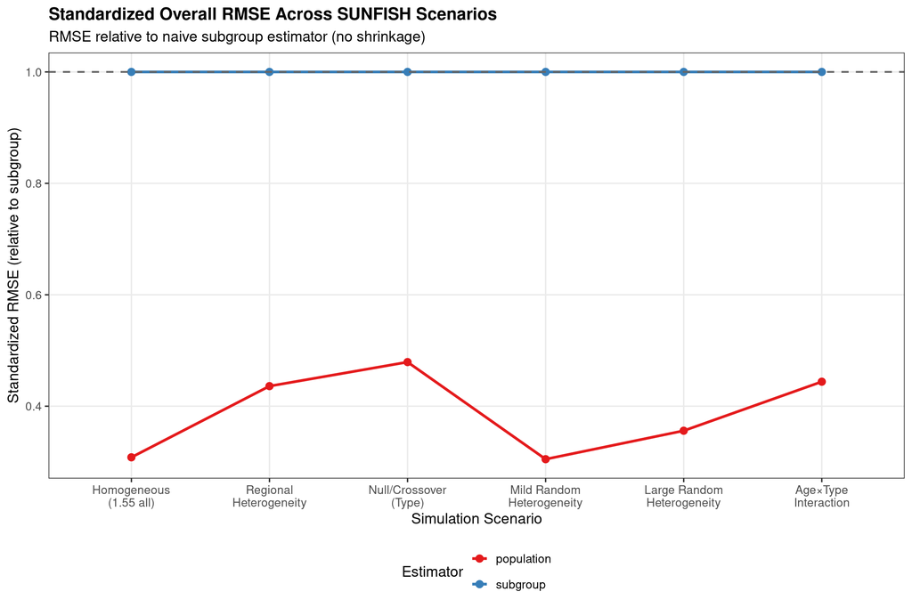

```r
# Define reference estimator (naive subgroup analysis)
reference_estimator_name <- "subgroup"

# Calculate baseline RMSE for standardization
baseline_rmse <- rmse_results %>%
  filter(estimator_name == reference_estimator_name) %>%
  select(scenario_no, rmse_baseline = rmse)

# Scenario labels for SUNFISH
scenario_labels <- c(
  `1` = "Homogeneous\n(1.55 all)",
  `2` = "Regional\nHeterogeneity",
  `3` = "Null/Crossover\n(Type)",
  `4` = "Mild Random\nHeterogeneity",
  `5` = "Large Random\nHeterogeneity",
  `6` = "Age×Type\nInteraction"
)

# Prepare plot data with standardized RMSE
plot_data <- rmse_results %>%
  left_join(baseline_rmse, by = "scenario_no") %>%
  mutate(
    standardized_rmse = rmse / rmse_baseline,
    scenario_name = factor(scenario_no, levels = names(scenario_labels), labels = scenario_labels)
  )

# Create standardized RMSE plot
ggplot(plot_data,
       aes(x = scenario_name, y = standardized_rmse,
           group = estimator_name, color = estimator_name)) +
  geom_line(size = 1.2) +
  geom_point(size = 3) +
  geom_hline(yintercept = 1.0, linetype = "dashed", color = "gray40", size = 0.8) +
  scale_color_brewer(palette = "Set1") +
  labs(
    title = "Standardized Overall RMSE Across SUNFISH Scenarios",
    subtitle = "RMSE relative to naive subgroup estimator (no shrinkage)",
    y = "Standardized RMSE (relative to subgroup)",
    x = "Simulation Scenario",
    color = "Estimator"
  ) +
  theme_bw(base_size = 14) +
  theme(
    plot.title = element_text(face = "bold", size = 16),
    axis.text.x = element_text(angle = 0, hjust = 0.5),
    legend.position = "bottom",
    legend.box = "vertical",
    panel.grid.minor = element_blank()
  ) +
  guides(color = guide_legend(nrow = 2))
```

## 8. Subgroup-Level Performance Metrics

```r
# Calculate performance metrics at subgroup level
subgroup_performance <- merged_df %>%
  filter(!is.na(truth_value)) %>%
  group_by(scenario_no, join_key, estimator_name) %>%
  summarise(
    truth_value = first(truth_value),
    truth_population = first(truth_population),

    # Performance metrics
    bias = mean(estimate_value - truth_value, na.rm = TRUE),
    rmse = sqrt(mean((estimate_value - truth_value)^2, na.rm = TRUE)),

    # Coverage (95% CI/credible interval)
    coverage = mean((truth_value >= ci_lower) & (truth_value <= ci_upper), na.rm = TRUE),

    n_sims = n(),
    .groups = 'drop'
  ) %>%
  mutate(
    # Flag heterogeneous subgroups (>10% difference from population effect)
    heterogeneous = abs(truth_value - truth_population) > 0.155  # 10% of 1.55
  )

# Replace NaN coverage with NA
subgroup_performance <- subgroup_performance %>%
  mutate(coverage = if_else(is.nan(coverage), NA_real_, coverage))

cat("✓ Calculated subgroup-level metrics\n")
```

```
## ✓ Calculated subgroup-level metrics
```

```r
cat("  - Total subgroup×estimator combinations:", nrow(subgroup_performance), "\n")
```

```
##   - Total subgroup×estimator combinations: 108
```

## 9. Performance Summary Table

```r
# Helper functions for formatting
display <- function(x, digits = 2) {
  formatC(x, format = "f", digits = digits)
}

getPercentage <- function(x, digits = 0) {
  val <- 100 * x
  ifelse(is.na(val), "NA",
         paste(formatC(val, digits = digits, format = "f"), "%", sep = ""))
}

# Overall summaries
sum_rmse_bias <- subgroup_performance %>%
  group_by(estimator_name) %>%
  summarise(
    rmse = paste(display(mean(rmse, na.rm = TRUE), 2),
                 " (", display(min(rmse, na.rm = TRUE), 2),
                 "-", display(max(rmse, na.rm = TRUE), 2), ")", sep = ""),
    abs_bias = paste(display(mean(abs(bias), na.rm = TRUE), 2),
                     " (", display(min(abs(bias), na.rm = TRUE), 2),
                     "-", display(max(abs(bias), na.rm = TRUE), 2), ")", sep = "")
  ) %>%
  arrange(estimator_name)

sum_coverage <- subgroup_performance %>%
  group_by(estimator_name) %>%
  summarise(
    coverage = ifelse(all(is.na(coverage)), "NA",
                      paste(getPercentage(mean(coverage, na.rm = TRUE)),
                            " (", getPercentage(min(coverage, na.rm = TRUE)),
                            "-", getPercentage(max(coverage, na.rm = TRUE)), ")", sep = ""))
  ) %>%
  arrange(estimator_name)

# Summaries by heterogeneity
sum_rmse_bias_het <- subgroup_performance %>%
  group_by(heterogeneous, estimator_name) %>%
  summarise(
    rmse = paste(display(mean(rmse, na.rm = TRUE), 2),
                 " (", display(min(rmse, na.rm = TRUE), 2),
                 "-", display(max(rmse, na.rm = TRUE), 2), ")", sep = ""),
    abs_bias = paste(display(mean(abs(bias), na.rm = TRUE), 2),
                     " (", display(min(abs(bias), na.rm = TRUE), 2),
                     "-", display(max(abs(bias), na.rm = TRUE), 2), ")", sep = ""),
    .groups = 'drop'
  ) %>%
  arrange(estimator_name)

sum_coverage_het <- subgroup_performance %>%
  group_by(heterogeneous, estimator_name) %>%
  summarise(
    coverage = ifelse(all(is.na(coverage)), "NA",
                      paste(getPercentage(mean(coverage, na.rm = TRUE)),
                            " (", getPercentage(min(coverage, na.rm = TRUE)),
                            "-", getPercentage(max(coverage, na.rm = TRUE)), ")", sep = "")),
    .groups = 'drop'
  ) %>%
  arrange(estimator_name)

# Get estimator names
estimator_names <- sort(unique(subgroup_performance$estimator_name))
estimator_rows <- paste("- ", estimator_names, sep = "")
n_estimators <- length(estimator_names)

# Filter estimators with coverage
estimators_with_coverage <- sum_coverage$estimator_name[sum_coverage$coverage != "NA"]
estimator_rows_coverage <- paste("- ", estimators_with_coverage, sep = "")
n_estimators_coverage <- length(estimators_with_coverage)

# Assemble table
performance_table <- data.frame(
  Criterion = c(
    "Root mean squared error (RMSE)", estimator_rows,
    "Absolute bias", estimator_rows,
    "Coverage of 95% CI/credible interval", estimator_rows_coverage
  ),
  All_Subgroups = c(
    " ", sum_rmse_bias$rmse,
    " ", sum_rmse_bias$abs_bias,
    " ", sum_coverage$coverage[sum_coverage$coverage != "NA"]
  ),
  Homogeneous = c(
    " ", with(sum_rmse_bias_het, rmse[!heterogeneous]),
    " ", with(sum_rmse_bias_het, abs_bias[!heterogeneous]),
    " ", with(sum_coverage_het, coverage[!heterogeneous & coverage != "NA"])
  ),
  Heterogeneous = c(
    " ", with(sum_rmse_bias_het, rmse[heterogeneous]),
    " ", with(sum_rmse_bias_het, abs_bias[heterogeneous]),
    " ", with(sum_coverage_het, coverage[heterogeneous & coverage != "NA"])
  )
)

# Calculate footnote info
n_scenarios <- n_distinct(subgroup_performance$scenario_no)
n_subgroups_per_scenario <- n_distinct(subgroup_performance$join_key)
total_subgroups <- n_scenarios * n_subgroups_per_scenario

count_het <- subgroup_performance %>%
  filter(estimator_name == estimator_names[1]) %>%
  group_by(scenario_no) %>%
  summarise(total_het = sum(heterogeneous))
total_het <- sum(count_het$total_het)
total_homo <- total_subgroups - total_het

# Display table
kbl(performance_table,
    caption = "Performance Metrics for SUNFISH Simulation",
    booktabs = TRUE,
    linesep = c("", rep("", n_estimators),
                "\\addlinespace", rep("", n_estimators),
                "\\addlinespace", rep("", n_estimators_coverage)),
    col.names = c("Criterion", "All subgroups", "Homogeneous", "Heterogeneous")) %>%
  kable_styling(bootstrap_options = c("striped", "hover", "condensed")) %>%
  footnote(
    general = c(
      paste("Summary across", total_subgroups, "subgroups (", n_subgroups_per_scenario,
            "subgroups ×", n_scenarios, "scenarios) including", total_homo,
            "homogeneous and", total_het, "heterogeneous subgroups."),
      "Heterogeneous subgroups defined as >10% difference from population effect (>0.155 points).",
      "Monte Carlo standard error of coverage ≈ 0.7% (1000 simulations, true coverage 95%)."
    ),
    general_title = ""
  )
```

Performance Metrics for SUNFISH Simulation

Criterion

All subgroups

Homogeneous

Heterogeneous

Root mean squared error (RMSE)

- population

1.05 (0.78-1.39)

NA

NA

- subgroup

2.34 (0.84-6.38)

2.32 (0.84-6.38)

2.42 (0.93-5.71)

Absolute bias

- population

0.57 (0.02-1.15)

NA

NA

- subgroup

0.53 (0.00-2.10)

0.61 (0.00-2.10)

0.29 (0.00-1.15)

Coverage of 95% CI/credible interval

- population

86% (73%-95%)

NA

NA

- subgroup

91% (69%-96%)

90% (69%-96%)

92% (79%-96%)

Summary across 108 subgroups ( 18 subgroups × 6 scenarios) including NA homogeneous and NA heterogeneous subgroups.

Heterogeneous subgroups defined as >10% difference from population effect (>0.155 points).

Monte Carlo standard error of coverage ≈ 0.7% (1000 simulations, true coverage 95%).

## 10. RMSE by Subgroup (Scenario 2 - Regional Heterogeneity)

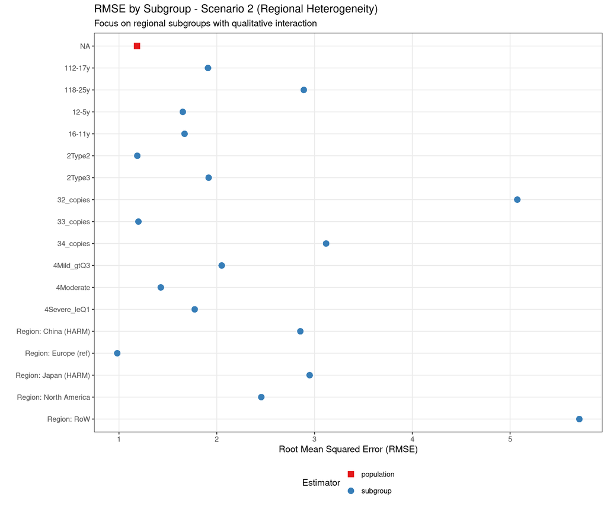

```r
# Focus on Scenario 2 (dramatic regional heterogeneity)
scenario2_data <- subgroup_performance %>%
  filter(scenario_no == "2") %>%
  mutate(
    # Clean up subgroup names for display
    subgroup_label = case_when(
      grepl("5Europe", join_key) ~ "Region: Europe (ref)",
      grepl("5NorthAmerica", join_key) ~ "Region: North America",
      grepl("5China", join_key) ~ "Region: China (HARM)",
      grepl("5Japan", join_key) ~ "Region: Japan (HARM)",
      grepl("5RoW", join_key) ~ "Region: RoW",
      TRUE ~ join_key
    )
  )

# Plot RMSE by subgroup for Scenario 2
ggplot(scenario2_data,
       aes(x = rmse, y = fct_rev(subgroup_label),
           color = estimator_name, shape = estimator_name)) +
  geom_point(size = 4, position = position_dodge(width = 0.4)) +
  scale_color_brewer(palette = "Set1") +
  scale_shape_manual(values = c(15:20, 0:10)) +
  labs(
    title = "RMSE by Subgroup - Scenario 2 (Regional Heterogeneity)",
    subtitle = "Focus on regional subgroups with qualitative interaction",
    x = "Root Mean Squared Error (RMSE)",
    y = "",
    color = "Estimator",
    shape = "Estimator"
  ) +
  theme_bw(base_size = 13) +
  theme(
    legend.position = "bottom",
    legend.box = "vertical",
    panel.grid.minor = element_blank()
  ) +
  guides(color = guide_legend(nrow = 2), shape = guide_legend(nrow = 2))
```

## 11. Bias Patterns Across Scenarios

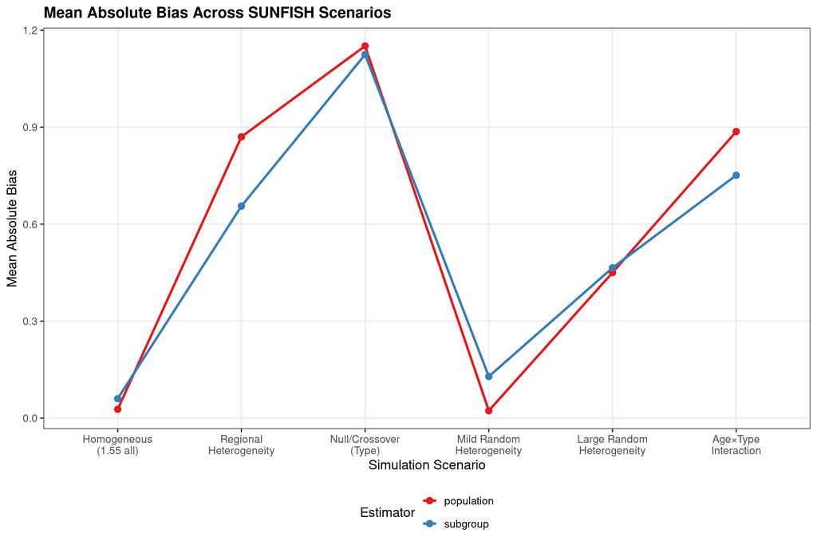

```r
# Calculate mean bias by scenario and estimator
bias_summary <- subgroup_performance %>%
  group_by(scenario_no, estimator_name) %>%
  summarise(
    mean_bias = mean(bias, na.rm = TRUE),
    mean_abs_bias = mean(abs(bias), na.rm = TRUE),
    .groups = 'drop'
  ) %>%
  mutate(
    scenario_name = factor(scenario_no, levels = names(scenario_labels),
                          labels = scenario_labels)
  )

# Plot mean absolute bias
ggplot(bias_summary,
       aes(x = scenario_name, y = mean_abs_bias,
           group = estimator_name, color = estimator_name)) +
  geom_line(size = 1.2) +
  geom_point(size = 3) +
  scale_color_brewer(palette = "Set1") +
  labs(
    title = "Mean Absolute Bias Across SUNFISH Scenarios",
    y = "Mean Absolute Bias",
    x = "Simulation Scenario",
    color = "Estimator"
  ) +
  theme_bw(base_size = 14) +
  theme(
    plot.title = element_text(face = "bold", size = 16),
    axis.text.x = element_text(angle = 0, hjust = 0.5),
    legend.position = "bottom",
    legend.box = "vertical",
    panel.grid.minor = element_blank()
  ) +
  guides(color = guide_legend(nrow = 2))
```